# FP2–V2. Mjerenje viskoznosti viskozimetrom s padajućom kuglicom

## Zadatak 1

Odredite viskoznost metanola kao funkcije temperature, u koracima od $5 \ \mathrm{^\circ C}$, koristeći se formulom (8). Potrebni podaci su:

- gustoća kuglice $\rho_\mathrm{k} = 2218 \ \mathrm{kg/m^3}$
- gustoća metanola $\rho_\mathrm{meth} = 792 \ \mathrm{kg/m^3}$
- konstanta $K = (5,78 \pm 0,01) \times 10^{−8} \ \mathrm{Pa \ m^3/kg}$

Nacrtajte funkciju $\eta(T)$ za metanol

Za ovaj zadatak bilo je potrebno izvršiti po barem 5 mjerenja na konstantnim temperaturama u razmacima od barem $5 \ \mathrm{^\circ C}$. Mjeri se vrijeme koje je potrebno kuglici koja se nalazi u cijevi sa metanolom da padne za unaprijed određeni razmak označen na instrumentu, viskozmetru, kojemu proizvođač određuje konstantu $K$ potrebnu za izračun viskoznosti prema idućem izrazu:

$$\eta=K(\rho_\mathrm{K}-\rho_\mathrm{meth})t$$

U tablici niže mogu se pronaći mjerenja za 7 različitih temperatura te graf ovisnosti viskoznosti temperature, kao i tablica izračunatih srednjih vrijednosti i nepouzdanosti vremena i viskoznosti. Nepouzdanost viskoznosti izračunata je idućom relacijom:

$$M_\eta=\sqrt{ \left ( \frac{\partial \eta}{\partial K}M_K \right )^2+ \left ( \frac{\partial \eta}{\partial t}M_t \right )^2 }=\eta \cdot \sqrt{ \left ( \frac{M_K}{K} \right )^2+ \left ( \frac{M_t}{t} \right )^2}$$

### Tablica podataka

|  | $t_1$ / $\mathrm{s}$ | $t_2$ / $\mathrm{s}$ | $t_3$ / $\mathrm{s}$ | $t_4$ / $\mathrm{s}$ | $t_5$ / $\mathrm{s}$ | $t_6$ / $\mathrm{s}$ | $t_7$ / $\mathrm{s}$ |
| --- | --- | --- | --- | --- | --- | --- | --- |
| 0 | 13,11 | 11,40 | 10,83 | 10,08 | 9,68 | 9,21 | 9,28 |
| 1 | 12,74 | 11,25 | 10,53 | 10,02 | 9,59 | 8,91 | 8,84 |
| 2 | 12,34 | 11,50 | 10,78 | 10,34 | 9,83 | 9,30 | 9,00 |
| 3 | 12,15 | 11,15 | 10,67 | 9,86 | 9,50 | 9,43 | 8,58 |
| 4 | 12,56 | 11,48 | 10,60 | 9,98 | 9,53 | 9,15 | 8,69 |
| $T$ / $\mathrm{K}$ | 296,15 | 301,15 | 306,15 | 311,15 | 317,15 | 323,15 | 328,15 |

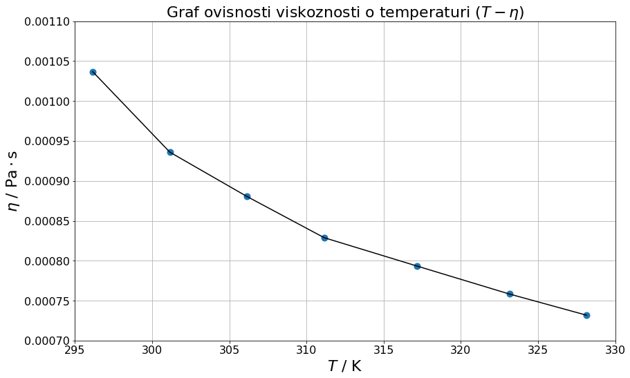

### Tablica rezultata

|  | $\overline{t}$ / $\mathrm{s}$ | $M_t$ / $\mathrm{s}$ | $\eta$ / $\mathrm{Pa \cdot s}$ | $M_\eta$ / $\mathrm{Pa \cdot s}$ |
| --- | --- | --- | --- | --- |
| 1 | 12,580 | 0,165741 | 0,001037 | 0,000014 |
| 2 | 11,356 | 0,067720 | 0,000936 | 0,000006 |
| 3 | 10,682 | 0,055444 | 0,000880 | 0,000005 |
| 4 | 10,056 | 0,079599 | 0,000829 | 0,000007 |
| 5 | 9,626 | 0,059548 | 0,000793 | 0,000005 |
| 6 | 9,200 | 0,086487 | 0,000758 | 0,000007 |
| 7 | 8,878 | 0,122898 | 0,000732 | 0,000010 |

## Rezultati

$$\eta_1 = ( 1,04 \pm 0,01 ) \ \mathrm{mPa \cdot s}$$

$$\eta_2 = ( 0,936 \pm 0,006 ) \ \mathrm{mPa \cdot s}$$

$$\eta_3 = ( 0,880 \pm 0,005 ) \ \mathrm{mPa \cdot s}$$

$$\eta_4 = ( 0,829 \pm 0,007 ) \ \mathrm{mPa \cdot s}$$

$$\eta_5 = ( 0,793 \pm 0,005 ) \ \mathrm{mPa \cdot s}$$

$$\eta_6 = ( 0,758 \pm 0,007 ) \ \mathrm{mPa \cdot s}$$

$$\eta_7 = ( 0,73 \pm 0,01 ) \ \mathrm{mPa \cdot s}$$

## Zadatak 2

Odredite viskoznost vakuumskog ulja pri sobnoj temperaturi i pri $45 \ \mathrm{^\circ C}$. Potrebni podaci su:

- gustoća kuglice $\rho_\mathrm{k} = 2218 \ \mathrm{kg/m^3}$
- gustoća vakuumskog ulja $\rho_\mathrm{ulje} = 860 \ \mathrm{kg/m^3}$
- konstanta $K = (7,79 \pm 0,03) \times 10^{−7} \ \mathrm{Pa \ m^3/kg}$

Postupak mjerenja identičan je kao u prvom zadatku samo što je u pitanju vakuumsko ulje te različita konstanta $K$ za korištenje relacije $\eta=K(\rho_\mathrm{K}-\rho_\mathrm{meth})t$.

## Tablica podataka

|  | $t_1$ / $\mathrm{s}$ | $t_2$ / $\mathrm{s}$ |
| --- | --- | --- |
| 1 | 116,34 | 38,32 |
| 2 | 112,08 | 37,92 |
| 3 | 110,74 | 33,08 |
| 4 | 117,28 | 35,44 |
| 5 | 118,26 | 40,68 |
| $T$ / $\mathrm{K}$ | 295,15 | 317,15 |

## Tablica rezultata

[output not shown]

## Rezultati

$$\eta_1 = ( 121,593 \pm 2 ) \ \mathrm{mPa \cdot s}$$

$$\eta_2 = ( 39,235 \pm 1 ) \ \mathrm{mPa \cdot s}$$

## Zadatak 3

Prikažite rezultate za metanol u grafu $\frac{1}{T} − \log\eta$ i provjerite valjanost relacije (2). Potrebno je upotrebljavati skalu apsolutne temperature. Odredite aktivacijsku energiju $\mu$ za metanol.

Kako bi se odredila aktivacijska energija $\mu$ potrebno je linearizirati idući izraz:

$$\eta(T)=Ae^{\frac{B}{T}}$$

koji će nakon toga izgledati ovako

$$\ln(\eta)=B \left ( \frac{1}{T} \right )+ \ln(A)$$

Taj izraz prepoznajemo kao jednadžbu pravca $y = ax + b$ te pripadne veličine: $$y = \ln(\eta)$$

$$x = \frac{1}{T}$$

$$a = B$$

$$b = \ln(A)$$

Nepouzdanost od $B$ biti će upravo jednaka parametru a:

$$B=a \\ M_{B}=\sqrt{\left ( \frac{\partial B}{\partial a} M_{a}\right )^2}= \sqrt{\left ( M_{a}\right )^2}=\left | M_{a} \right |$$

te kako bi se izračunala aktivacijka energija $\mu=k_\mathrm{B}B$ potrebno je pronaći i nepouzdanost ovisnih veličina:

$$M_\mu=\sqrt{ \left ( \frac{\partial \mu}{\partial B} M_B \right )^2 }= \mu \cdot \frac{M_B}{B}$$

Sada su svi potrebni izrazi spremni te možemo krenuti sa MNK.

Transformirani podaci nad kojima se provodi MNK su u tablici niže kao i vizualni prikaz.

## Tablica prilagođenih podataka za MNK

|  | $1/T$ / $\mathrm{K^{-1}}$ | $\ln(\eta)$ |
| --- | --- | --- |
| 1 | 0,003377 | -6,871540 |
| 2 | 0,003321 | -6,973902 |
| 3 | 0,003266 | -7,035088 |
| 4 | 0,003214 | -7,095479 |
| 5 | 0,003153 | -7,139181 |
| 6 | 0,003095 | -7,184445 |
| 7 | 0,003047 | -7,220072 |

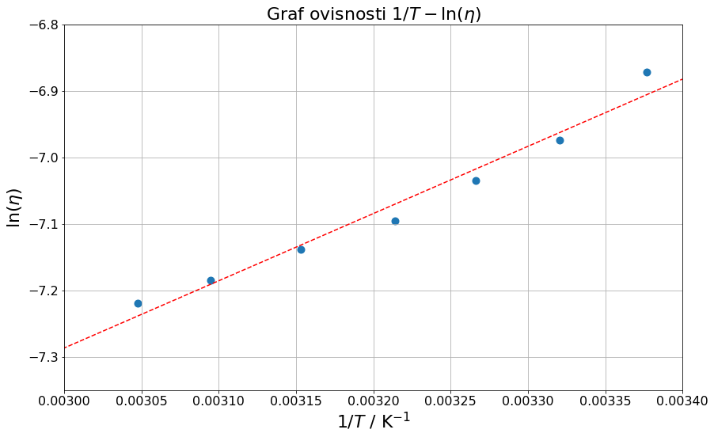

## Rezultati MNK

$a = 1010.7093963508239 ± 79.05631475956311$

$b = -10.318987185893898 ± 0.25395101276234794$

$$a = 1010 ± 79$$

$$b = -10.3 ± 0.3$$

## Rezultat

$\mu = (1,3957896763604878 \pm 0,10917677068295665) \times 10^{-20} \ \mathrm{J}$

$$\mu = (1,4 \pm 0,1) \times 10^{-20} \ \mathrm{J}$$

## Zaključak

#### Zadatak 1

Porastom temperature viskoznost se očekivano smanjuje. Odmah je vidljivo kako mjereni podaci dobro aproksimiraju padajuću eksponencijalnu ovisnost što znači da za jako velike temperature viskoznost nikada neće postati nula te uvijek postoji njen efekt. Za suprotnu stranu kada bi smo temperaturu pustili prema apsolutnoj nuli viskoznost jako naglo raste što intuitivno možemo potvrditi da ima smisla, odnosno dogodi se prijelaz u kruto stanje.

#### Zadatak 2

Ne možemo pričati o ovisnosti viskoznosti no mislim kako bi ovaj podatak trebao biti preciznije izmjeren obzirom da sam imao više prostora za pogreške jer loptica jako sporo pada.